# Analysis of crystal data, especially volume-optimal cycle and tightened-volume

In this article we will analyze the data of a 3x3 cubic grid. Analyze noise-added data instead of a perfect cubic grid. Here, we analyze the first-order persistent diagram.

First, calculate the persistent diagram.

```bash
python3 -m homcloud.pc_alpha -D -I -d 3 --no-square cubic_crystal.txt cubic_crystal.idiagram
```

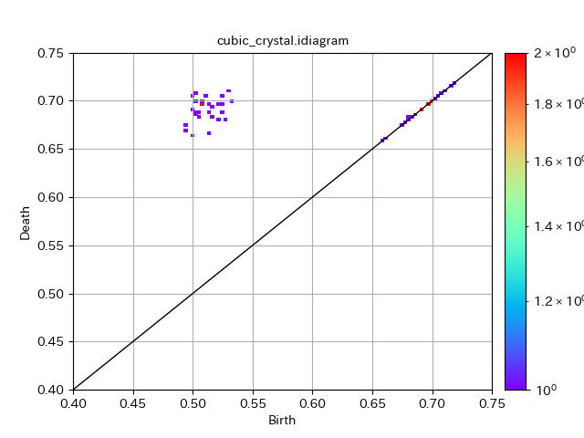

```bash
python3 -m homcloud.plot_PD -d 1 -x 0.4:0.75 -l cubic_crystal.idiagram -o cubic_crystal_PD1.png
display < cubic_crystal_PD1.png
```

Points are concentrated around birth 0.5, death 0.7. This corresponds to a ring made by a square with a side length of 1 in a cubic lattice.

Birth corresponds to 1/2 of 1 = 0.5, and death corresponds to 1/2 of $\sqrt{2}$ (diagonal length of square) = 0.70.. . The birth-death pair spreads as much as the noise is added.

Next, let's calculate the ring corresponding to this birth-death pair using volume-optimal cycle (optimal volime). To start with, display all birth-death pairs.

```bash
python3 -m homcloud.dump_diagram -d 1 cubic_crystal.idiagram -S no
```

```
0.6586306291340102 0.6590304640137215
0.6606323646333819 0.6619347226903078
0.49987336207987887 0.6627136731813481
0.5121519314069597 0.667922518921654
0.4949660182760674 0.6682139473572098
0.6745095199109901 0.6753672748153773
0.49455004783609063 0.6761439650496468
0.6776483958747631 0.6776602955543044
0.6793140020774003 0.6803759145663726
0.5269822633697324 0.6804175382521039
0.5206692998733057 0.6811089887096263
0.505786855468919 0.6832301479748246
0.6807788542625179 0.683299330068848
0.5165543624337156 0.6836012939071158
0.6838155374761266 0.6838686796750283
0.6858197481159733 0.6858764556032431
0.502928397276293 0.6868370231473592
0.506101119739788 0.6876344979407797
0.5147215515974617 0.6880312826094713
0.5252097936511079 0.6890763453976233
0.5025608575422964 0.689171867637253
0.5002435126147523 0.6899910037142132
0.6911565942161753 0.6915995803753984
0.6918926113623273 0.6922603105982803
0.5159753174844722 0.6937171904705404
0.5138802936339488 0.6964370646579494
0.6966110684017212 0.6966252119546423
0.6967433149222299 0.6967481686187554
0.5229799688832133 0.6967755570967225
0.5232724066175749 0.6968997411234836
0.5089799004945281 0.6970068037470472
0.5091621008021502 0.6975775524547941
0.5313802366272908 0.6984609668496734
0.6988049641938592 0.6988176064188562
0.5032343340877725 0.6989326288595414
0.6993780174841242 0.6998033875223008
0.5081893902733595 0.700043846984738
0.7027127347365761 0.7034988904024334
0.5116284154743329 0.7046639222598844
0.7049844105242548 0.705513351996927
0.4995262316670215 0.7058238604707326
0.5250775786934011 0.7060074425166798
0.7064991107095185 0.7064997938645462
0.5031998471791083 0.7066449404741557
0.7101245900928161 0.7107039627866102
0.5301676220667683 0.7108090671584363
0.7146951713594543 0.7149224052333443
0.7175576975195354 0.7175926315987486
0.829719780053145 0.8297204044849945
0.8360632560378511 0.8360867659314453
0.8398918503065594 0.8401477181124667
```

Calculate the volume-optimal cycle of the pair (0.5206692998733057, 0.6811089887096261). Above all, let's display with paraview.

```bash
python3 -m homcloud.optimal_volume -d 1 -x 0.5206692998733057 -y 0.6811089887096261 -P cubic_crystal.idiagram
```

In this case, a square appears. Let's actually display the vertices. Save it in `voc-1.json` and extract the information with the program `jq`.

```bash
python3 -m homcloud.optimal_volume -d 1 -x 0.5206692998733057 -y 0.6811089887096261 -j voc-1.json cubic_crystal.idiagram
jq -r '.result[0]."boundary-points"[] | @tsv'  < voc-1.json
```

```
-0.022255800483552014	0.023659139352163072	0.9768963895898605
0.04563001802111903	-0.022869567479032318	1.9533706361668377
-0.03087908081352836	0.9643067747567892	1.0279201400018765
-0.042979431936026984	1.0133969245072298	2.0051992217833803
```

You can see that it consists of 4 points (0,0,1), (0,0,2), (0,1,1), (0,1,2).

Do the same analysis for the pair (0.5091621008021502, 0.6975775524547941).

```bash
# 可視化
python3 -m homcloud.optimal_volume -d 1 -x 0.5091621008021502 -y 0.6975775524547941 -P cubic_crystal.idiagram
```

```bash
# 頂点を計算
python3 -m homcloud.optimal_volume -d 1 -x 0.5091621008021502 -y 0.6975775524547941 -j voc-2.json cubic_crystal.idiagram
jq -r '.result[0]."boundary-points"[] | @tsv ' < voc-2.json
```

```
0.010981508105209217	2.045199500969634	0.036362660302841854
0.0072809064876125165	1.9604875237665966	0.9625477057099272
1.0206532366788403	1.979286245962941	0.00858106673754453
0.980187842201634	2.0335467610373645	1.0341102828474105
1.9611531711740877	1.992047898713316	0.026019232881991525
1.9544148121435598	1.9779564025826202	1.044223634673405
```

You can see that a rectangular shape consisting of 6 vertices is calculated. It is said that this birth-death pair corresponds to a square with a side length of 1, but in this case a rectangle is obtained. In fact, persistent homology often shows multiple unit structures attached to each other.

Here, how "reliable" is this rectangle? To sum up, how robust is it to noise? Really, this kind of thing "with multiple units" are unstable against noise.

Then, is there something "more stable against noise"? HomCloud implements a tightened volume, and that can be used.

So, Let's calculate the tightened volume. You can calculate this by giving `homcloud.optimal_volume` the option `--tightened-volume THRESHOLD`.

```bash
# 可視化
python3 -m homcloud.optimal_volume -d 1 -x 0.5091621008021502 -y 0.6975775524547941 --tightened-volume 0.05 \
  --no-optimal-volume on -P cubic_crystal.idiagram
```

```bash
# 頂点を表示
python3 -m homcloud.optimal_volume -d 1 -x 0.5091621008021502 -y 0.6975775524547941 --tightened-volume 0.05 \
  --no-optimal-volume on -j tv-2.json cubic_crystal.idiagram
jq -r '.result[0]."tightened-volume"."boundary-points"[] | @tsv ' < tv-2.json
```

```
1.9611531711740877	1.992047898713316	0.026019232881991525
1.9544148121435598	1.9779564025826202	1.044223634673405
0.980187842201634	2.0335467610373645	1.0341102828474105
1.0206532366788403	1.979286245962941	0.00858106673754453
```

In this analysis, the volume-optimal cycle does not need to be calculated, so the calculation is ommited by adding `--no-optimal-volume on`. Hereupon, a square with four vertices is obtained indeed.

Finally, let's compare volume-optimal cycle and tightened-volume for all birth-death pairs around (0.5, 0.7). By specifying `-X "[0.45:0.55]" -Y "[0.65:0.75]"`, the calculation will be performed for everything in this range.

```bash
python3 -m homcloud.optimal_volume -d 1 -X "[0.45:0.55]" -Y "[0.65:0.75]" -j voc-all.json cubic_crystal.idiagram
```

Here, only the number of vertices in each cycle is displayed. Count using the function of `jq`.

```bash
jq  '.result[]."boundary-points" | length'  < voc-all.json
```

```
4
4
4
4
4
4
4
4
6
4
4
4
6
6
4
4
4
4
4
6
4
4
8
6
10
6
11
6
```

You can see that some things other than 4 vertices appear.

Next, try using a tightend volume.

```bash
python3 -m homcloud.optimal_volume -d 1 -X "[0.45:0.55]" -Y "[0.65:0.75]" --tightened-volume 0.05 \
  --no-optimal-volume on -j tv-all.json cubic_crystal.idiagram
```

```bash
jq  '.result[]."tightened-volume"."boundary-points" | length'  < tv-all.json
```

```
4
4
4
4
4
4
4
4
4
4
4
4
4
4
4
4
4
4
4
4
4
4
4
4
4
4
4
4
```

All number of vertices are 4. This is the expected result.

## Note

The optimal volume is the area inside the volume-optimal cycle. What we are actually calculating is the optimal volume and the volume-optimal cycle is at the boundary.

An argument of `--tightened-volume`, 0.05 means "examine stable information even with about this much noise added". Here, the value is determined based on the distribution range of the birth-death pair near (0.5, 0.7).

At present, there is no mathmatical guarantee that the tightened volume used here really sees "stable information". Perhaps some mathematical characterization is possible, but that is for the future.

In addition to `--tightened-volume`, there are similar functions such as `--tightened-subvolume` and `--owned-volume`. Although the calculation algorithm is different, the results obtained are similar. These use the calculation results of the volume-optimal cycle, so remove `-no-optimal-volume on`.